# Global Moran’s I

## rows

### 2023 Moran’s I 0.100 `pseudo P-value 0.037`

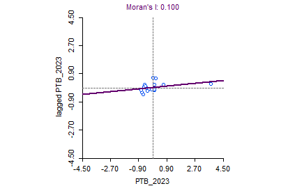

### 2022 Moran’s I 0.121 `pseudo P-value 0.029`

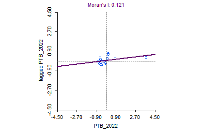

### 2021 Moran’s I 0.098 `pseudo P-value 0.033`

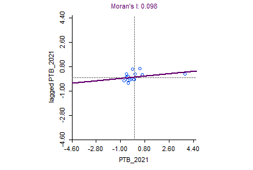

### 2020 Moran’s I 0.122 `pseudo P-value 0.015`

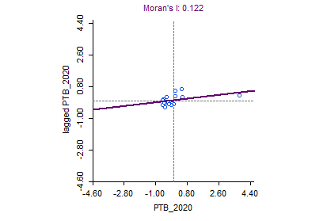

### 2019 Moran’s I 0.097 `pseudo P-value 0.025`

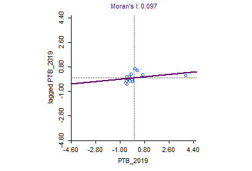

## rows

### 2018 Moran’s I 0.097 `pseudo P-value 0.030`

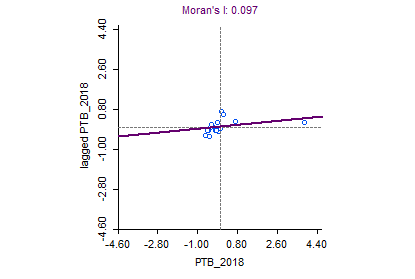

### 2017 Moran’s I 0.143 `pseudo P-value 0.016`

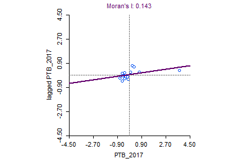

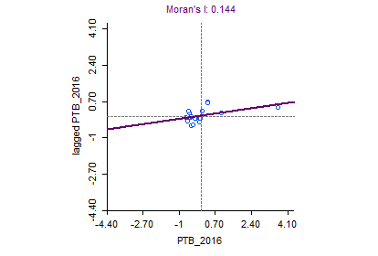

### 2015 Moran’s I 0.081 `pseudo P-value 0.045`

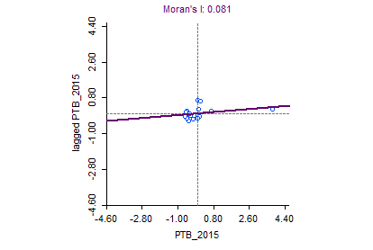

### 2014 Moran’s I 0.058 `pseudo P-value 0.040`

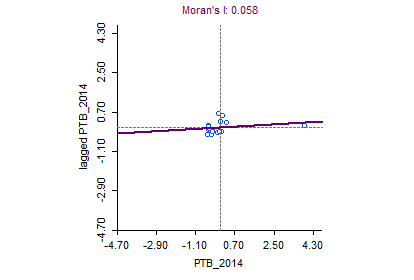

## rows

**The Moran scatter plot of TB incidences in Mueang Khon Kaen District, 2014–2023**

📖 Pulmonary tuberculosis refers to TB cases diagnosed by a physician using at least one of the A15, A16, and A19 ICD-10 codes (the 10th revision of the International Classification of Diseases). We include A19, miliary tuberculosis, as the primary site of TB infection is the lung, from where it spreads through the bloodstream to other parts of the body.

📝 The results show that when exploring the global detection of pulmonary tuberculosis, Moran's indices were found to be significantly positive (p-value < 0.05) in every year from 2014 to 2023, indicating spatial clustering across the study area during this period.

# Local Moran’s I

## rows

### 2023

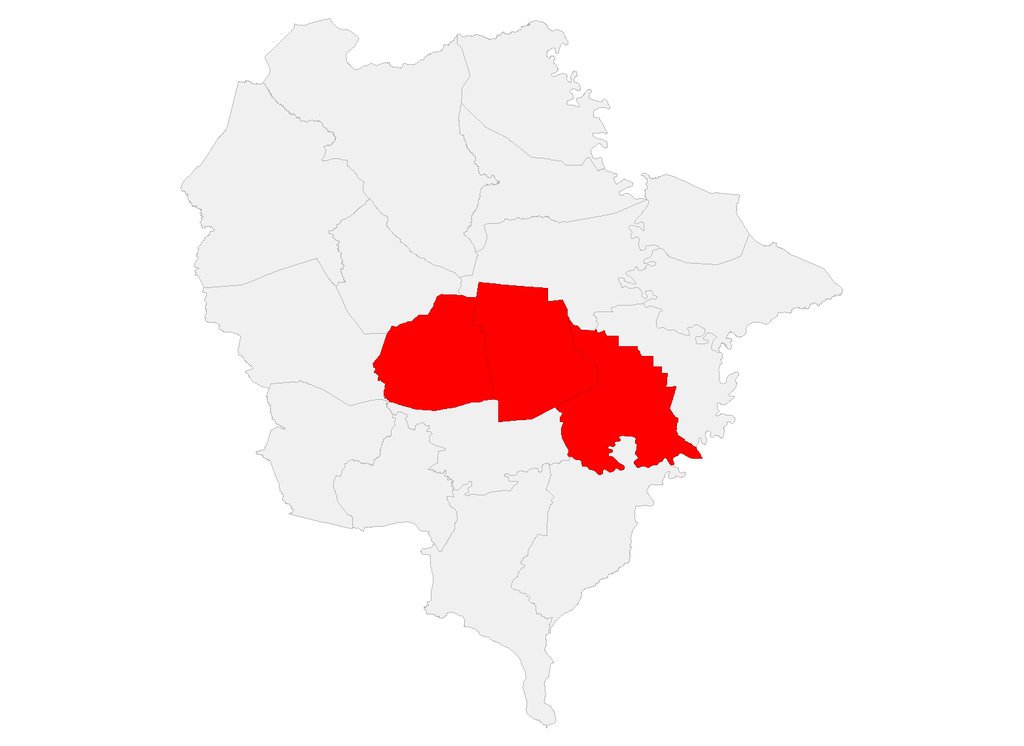

### 2022

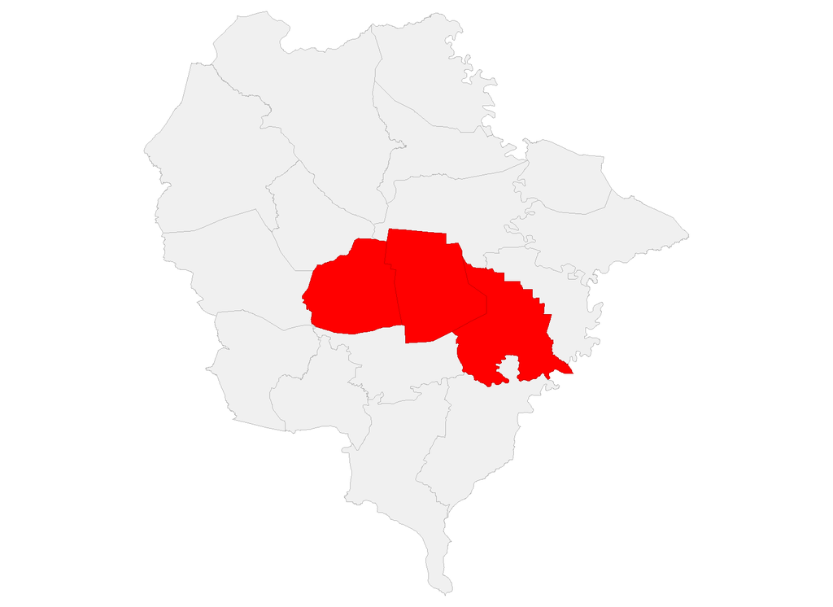

### 2021

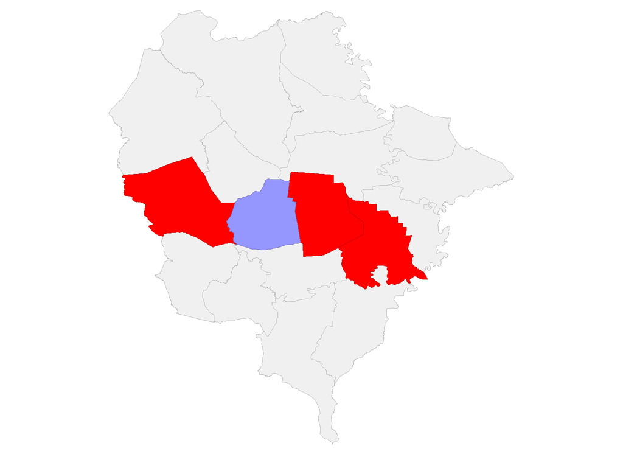

### 2020

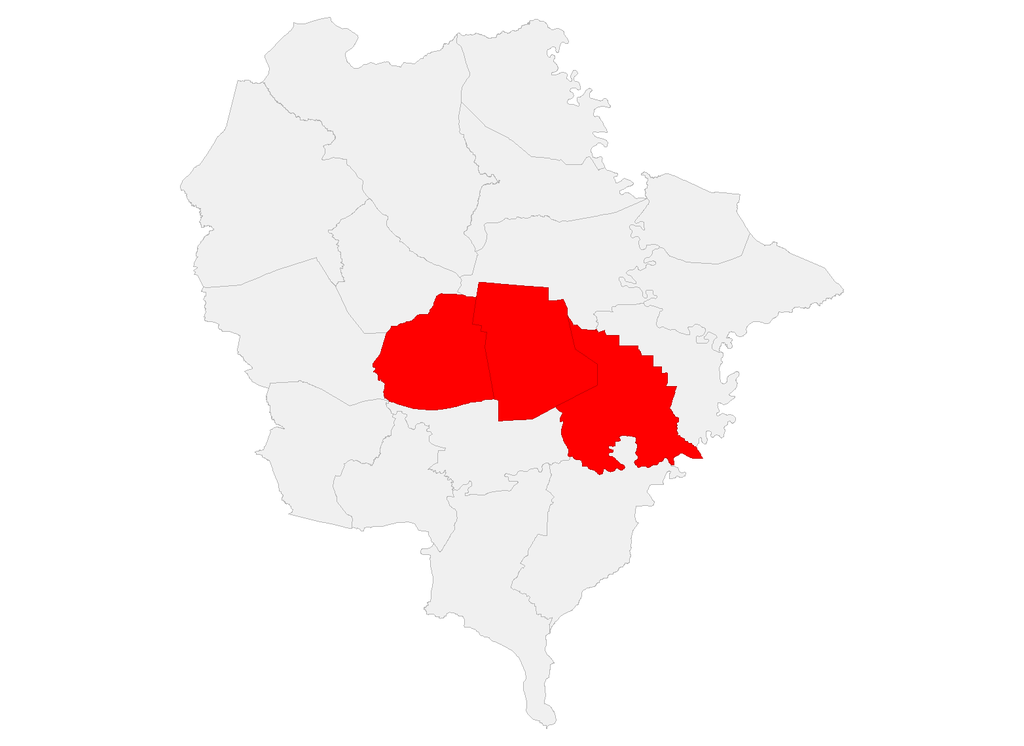

### 2019

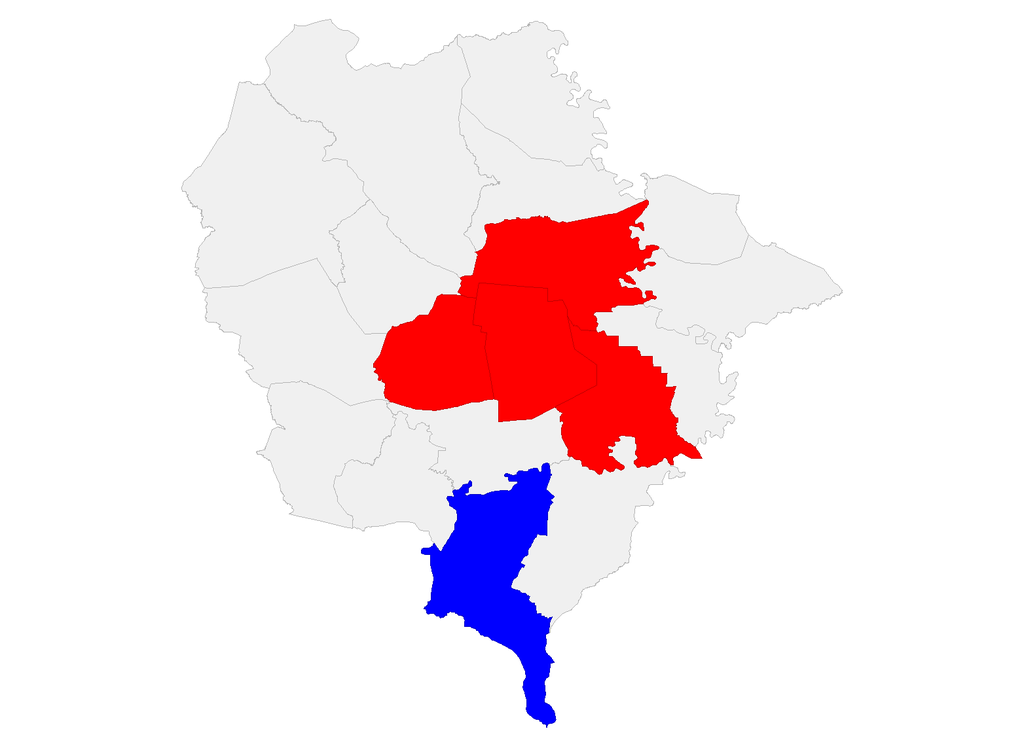

## rows

### 2018

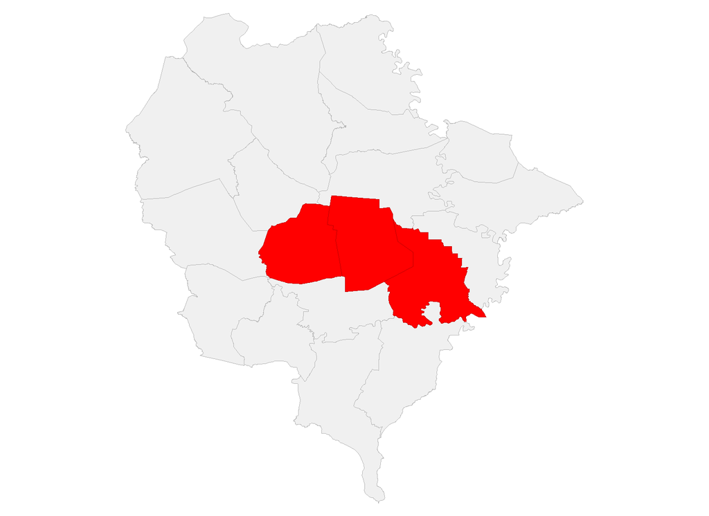

### 2017

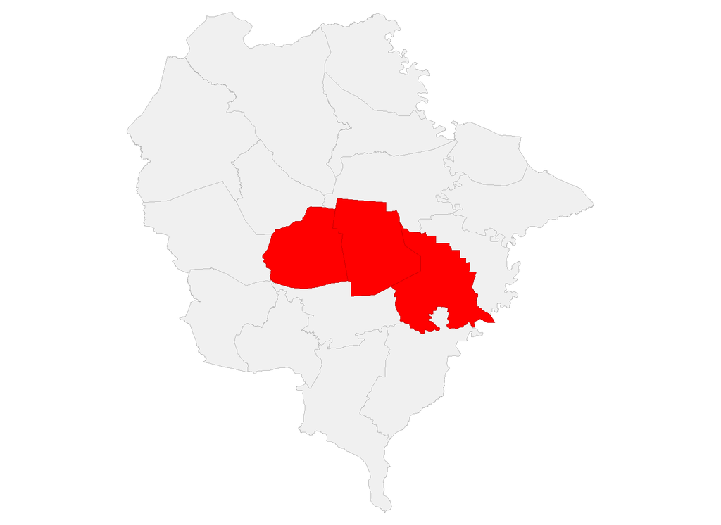

### 2016

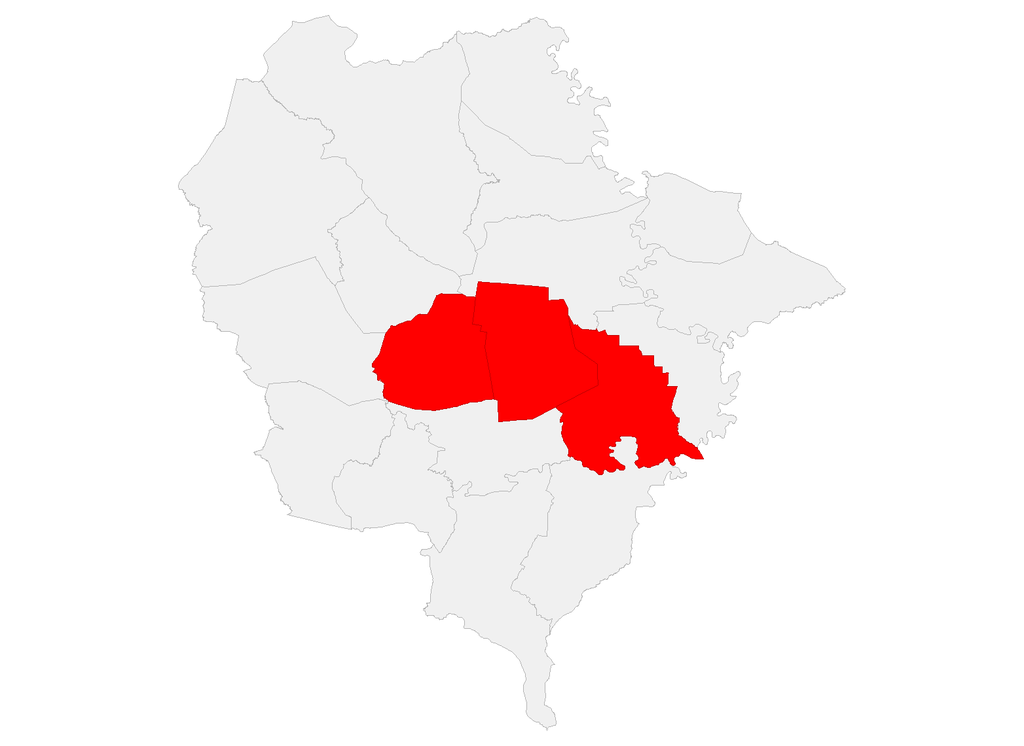

### 2015

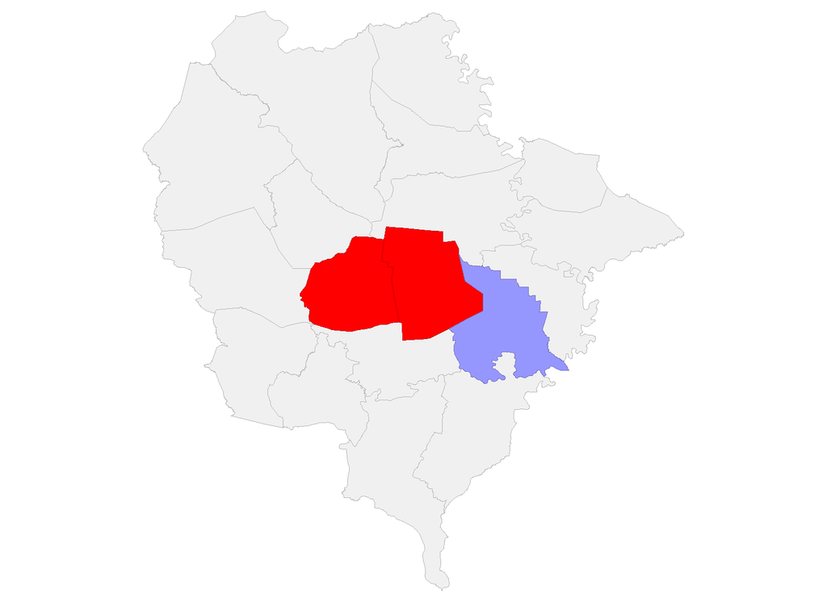

### 2014

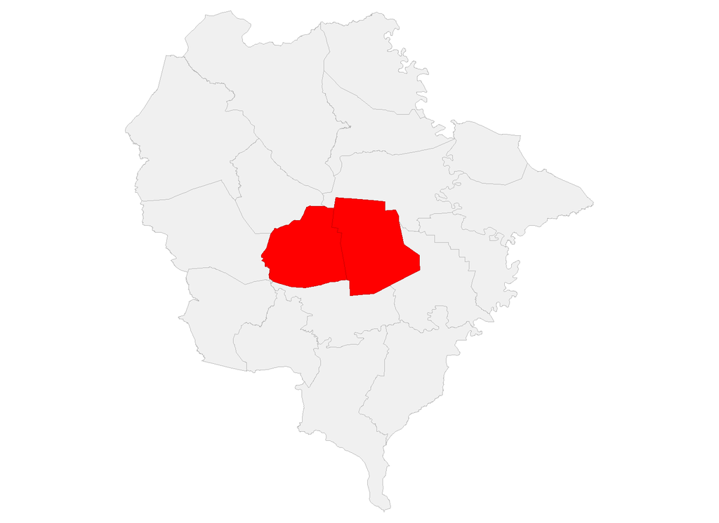

**LISA Cluster Map** Not Significant High-High Low-Low Low-High High-Low

[interactive chart not shown]